# Final Project: Airbnb New User Bookings Prediction

Yangying Xu, Mingyang Li, Jun Zhang, Weijia Mi

2018/12/8

## 1. Introduction to data

In train_user_2.csv and test_users.csv file, data provided a list of users along with some related information and statistics such as gender, language and signup flow. Sessions.csv file gives information about web sessions log for users. The column ‘country_destination’ in train file is the record of destination of each user and it is the target variable to predict in the test set. There are 12 possible outcomes of the destination countries: ‘US’, ‘FR’, ‘CA’, ‘GB’, ‘ES’, ‘IT’, ‘PT’, ‘NL’,‘DE’, ‘AU’, ‘NDF’ (no destination found), and ‘other’. Countries.csv also provides information about 10 country destination. All users in test file are new user and are from the USA, therefore, we are required to predict which country their first booking destination will be.

The training and test sets are split by dates. The training set includes users dataset dates back to 2010 and in the test set, all the new users are people with first activities after 7/1/2014 . The following part gives a detailed description of variables in files.

File descriptions 1.train_users.csv - the training set of users 2.test_users.csv - the test set of users id: user id ；  
date_account_created: the date of account creation ； timestamp_first_active: timestamp of the first activity, note that it can be earlier than date_account_created or date_first_booking because a user can search before signing up ；  
date_first_booking: date of first booking ；  
gender ；  
age ；  
signup_method: Users can choose to register directly or log in with facebook or google account ；  
signup_flow: the page a user came to signup up from ； language: international language preference ； affiliate_channel: what kind of paid marketing ； affiliate_provider: where the marketing is e.g. google, craigslist, other ；  
first_affiliate_tracked: whats the first marketing the user interacted with before the signing up ；  
signup_app: users can choose web, andrew, ios or Moweb as media to browse information on Airbnb ；  
first_device_type: the phone or computer system that users use when they first browse Airbnb ；  
first_browser: the browser the user used when browsing Airbnb for the first time ；  
country_destination: this is the target variable you are to predict 3.sessions.csv - web sessions log for users user_id: to be joined with the column ‘id’ in users table 4.countries.csv - summary statistics of destination countries in this dataset and their locations 5.age_gender_bkts.csv - summary statistics of users’ age group, gender, country of destination

## 2. Business question

```r
# Import data
train_user <- read_csv("~/myfirstR/all/train_users_2.csv")
countries <- read_csv("~/myfirstR/all/countries.csv")
test_user <- read_csv("~/myfirstR/all/test_users.csv")
# Transfrorm data frame into data table
train_user <- as.data.table(train_user)
countries <- as.data.table(countries)

# Set key for joining for both tables
setkey(train_user, country_destination)
setkey(countries, country_destination)
merged_user <- countries[train_user, on = "country_destination"]

# Drop key
setkey(train_user, NULL)
setkey(countries, NULL)

# Summarize data
summary(train_user)
```

```
##       id            date_account_created timestamp_first_active
##  Length:213451      Min.   :2010-01-01   Min.   :2.009e+13
##  Class :character   1st Qu.:2012-12-26   1st Qu.:2.012e+13
##  Mode  :character   Median :2013-09-11   Median :2.013e+13
##                     Mean   :2013-06-25   Mean   :2.013e+13
##                     3rd Qu.:2014-03-06   3rd Qu.:2.014e+13
##                     Max.   :2014-06-30   Max.   :2.014e+13
##
##  date_first_booking      gender               age
##  Min.   :2010-01-02   Length:213451      Min.   :   1.00
##  1st Qu.:2012-12-02   Class :character   1st Qu.:  28.00
##  Median :2013-09-11   Mode  :character   Median :  34.00
##  Mean   :2013-07-04                      Mean   :  49.67
##  3rd Qu.:2014-04-04                      3rd Qu.:  43.00
##  Max.   :2015-06-29                      Max.   :2014.00
##  NA's   :124543                          NA's   :87990
##  signup_method       signup_flow       language         affiliate_channel
##  Length:213451      Min.   : 0.000   Length:213451      Length:213451
##  Class :character   1st Qu.: 0.000   Class :character   Class :character
##  Mode  :character   Median : 0.000   Mode  :character   Mode  :character
##                     Mean   : 3.267
##                     3rd Qu.: 0.000
##                     Max.   :25.000
##
##  affiliate_provider first_affiliate_tracked  signup_app
##  Length:213451      Length:213451           Length:213451
##  Class :character   Class :character        Class :character
##  Mode  :character   Mode  :character        Mode  :character
##
##
##
##
##  first_device_type  first_browser      country_destination
##  Length:213451      Length:213451      Length:213451
##  Class :character   Class :character   Class :character
##  Mode  :character   Mode  :character   Mode  :character
##
##
##
##
```

## 3.Exploratory Data Analysis

```r
# To get introduce to our dataset and visualize the table
introduce(merged_user)
```

```
##      rows columns discrete_columns continuous_columns all_missing_columns
## 1: 213451      22               14                  8                   0
##    total_missing_values complete_rows total_observations memory_usage
## 1:              1026420         60614            4695922     48680240
```

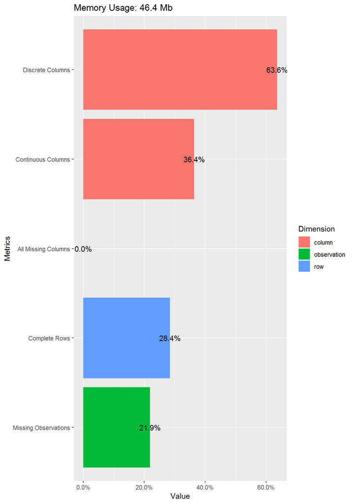

```r
plot_intro(merged_user)
```

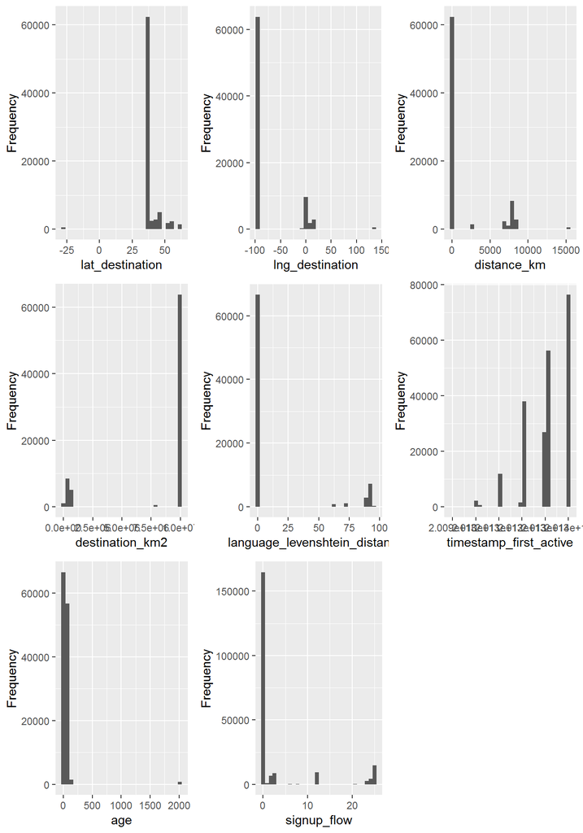

```r
# Draw histograms to visualize frequency distributions for all continous variables
plot_histogram(merged_user)
```

```
## 4 columns ignored with more than 50 categories.
## id: 213451 categories
## date_account_created: 1634 categories
## date_first_booking: 1977 categories
## first_browser: 52 categories
```

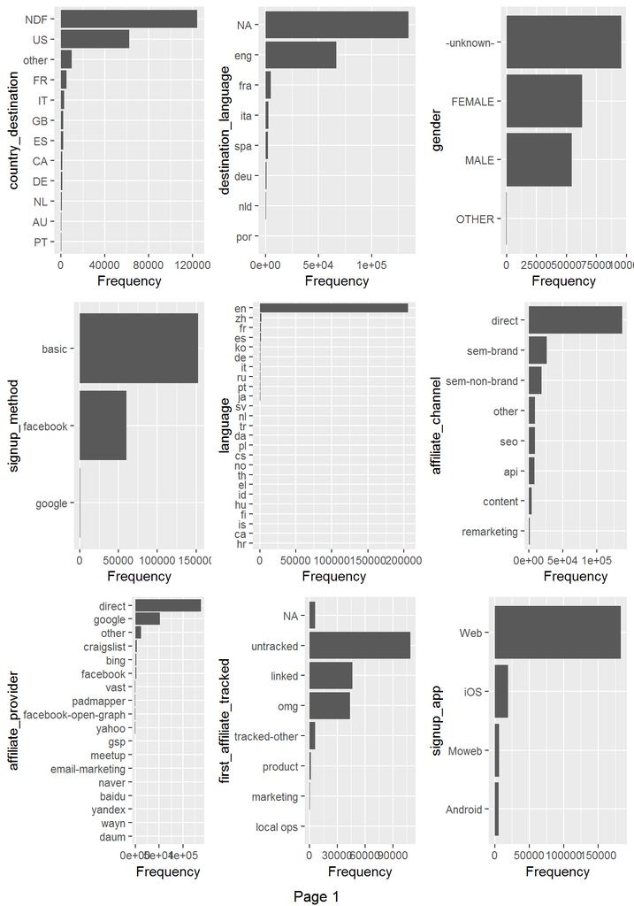

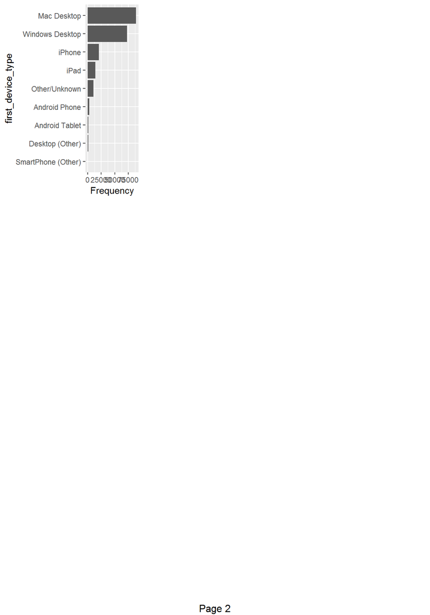

```r
# Draw bar charts to visualize frequency distributions for all discrete variables
plot_bar(merged_user)
```

We can see that the date in our data table is composed of year, month and day. We want to see seasonal changes in registration and activation. So here we need to seperate year, month and day into different columns.

```r
# Split the date of date_account_created and timestamp_first_active
merged_user$year_account_created <- year(merged_user$date_account_created)
merged_user$month_account_created <- month(merged_user$date_account_created)
merged_user$day_account_created <-day(merged_user$date_account_created)
merged_user <- within(merged_user, year_month_account_created <- sprintf("%d-%02d", year_account_created, month_account_created))

merged_user$year_first_active <- substr(merged_user$timestamp_first_active,1,4)
merged_user$month_first_active <- substr(merged_user$timestamp_first_active,5,6)
merged_user$day_first_active <- substr(merged_user$timestamp_first_active,7,8)
merged_user$date_first_active <- substr(merged_user$timestamp_first_active,1,8)
merged_user$date_first_active <-ymd(merged_user$date_first_active)
merged_user <- within(merged_user, year_month_first_active <- sprintf("%s-%02s", year_first_active, month_first_active))

merged_user$timestamp_first_active <-NULL
```

```r
# Delete the date_first_booking colunm
merged_user$date_first_booking <- NULL
```

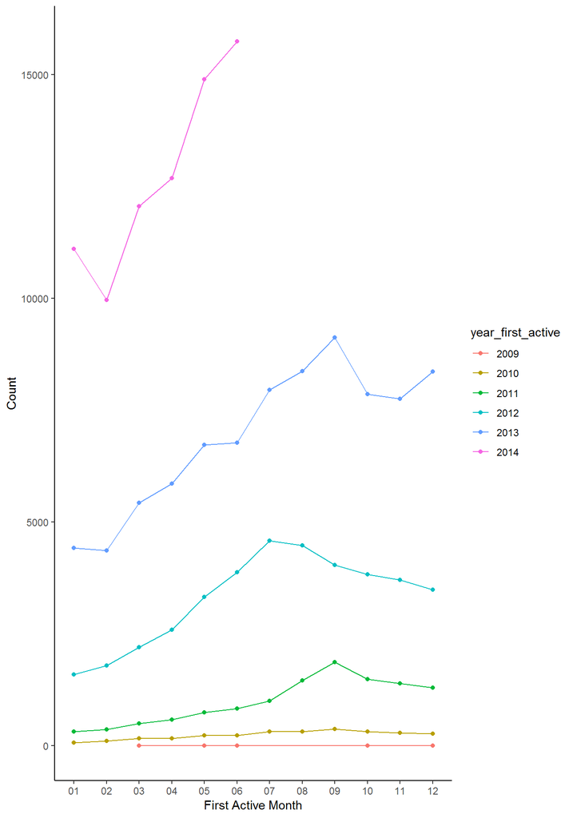

```r
# Make plot of sensonal first active
merged_user_group1 <- merged_user %>%
  group_by(year_month_first_active, year_first_active, month_first_active) %>%
  dplyr::summarise(n = n())

ggplot(merged_user_group1, aes(x = month_first_active, y = n, group = year_first_active, color = year_first_active)) +
  geom_point() +
  geom_line() +
  theme_classic() +
  xlab("First Active Month") +
  ylab("Count")
```

From the graph shown above, we can see that from 2009 to 2014, there is an increasing trend in the number of users of Airbnb. And in general, there are more first active users in summer than in winter.

In order to understand the preferences of users of different ages, we decided to categorize age into groups and analyze the preferences of users of different ages for destinations and electronic devices.

```r
# Clean attribute Age
merged_user$age[is.na(merged_user$age)] <- -1
merged_user$age[merged_user$age > 1900] <- 2015 - merged_user$age[merged_user$age > 1900]
merged_user$age[(merged_user$age < 10) & (merged_user$age >= 0)] <- 0
merged_user$age[(merged_user$age < 20) & (merged_user$age >= 10)] <- 10
merged_user$age[(merged_user$age < 30) & (merged_user$age >= 20)] <- 20
merged_user$age[(merged_user$age < 40) & (merged_user$age >= 30)] <- 30
merged_user$age[(merged_user$age < 50) & (merged_user$age >= 40)] <- 40
merged_user$age[(merged_user$age < 60) & (merged_user$age >= 50)] <- 50
merged_user$age[(merged_user$age < 70) & (merged_user$age >= 60)] <- 60
merged_user$age[(merged_user$age < 80) & (merged_user$age >= 70)] <- 70
merged_user$age[(merged_user$age < 90) & (merged_user$age >= 80)] <- 80
merged_user$age[(merged_user$age < 100) & (merged_user$age >= 90)] <- 90
merged_user$age[merged_user$age >= 100] <- 100
merged_user$age[merged_user$age == -1] <- NA
```

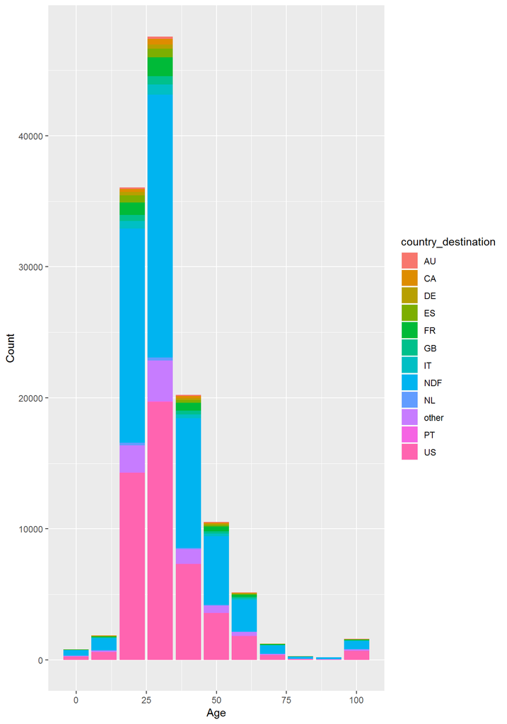

```r
# Make plot of age by destination country
ggplot(merged_user, aes(x = age , fill = country_destination)) +
  geom_bar() +
  xlab("Age") +
  ylab("Count")
```

From the graph above, we can see that for all age group, people are more likely to travel within the USA, which is expected because all the users in this dataset are from the USA. In addition, destinations in Europe is more popular in younger generations (20 ~ 40). Lastly, people in age 20 ~ 40 are more likely to travel overall.

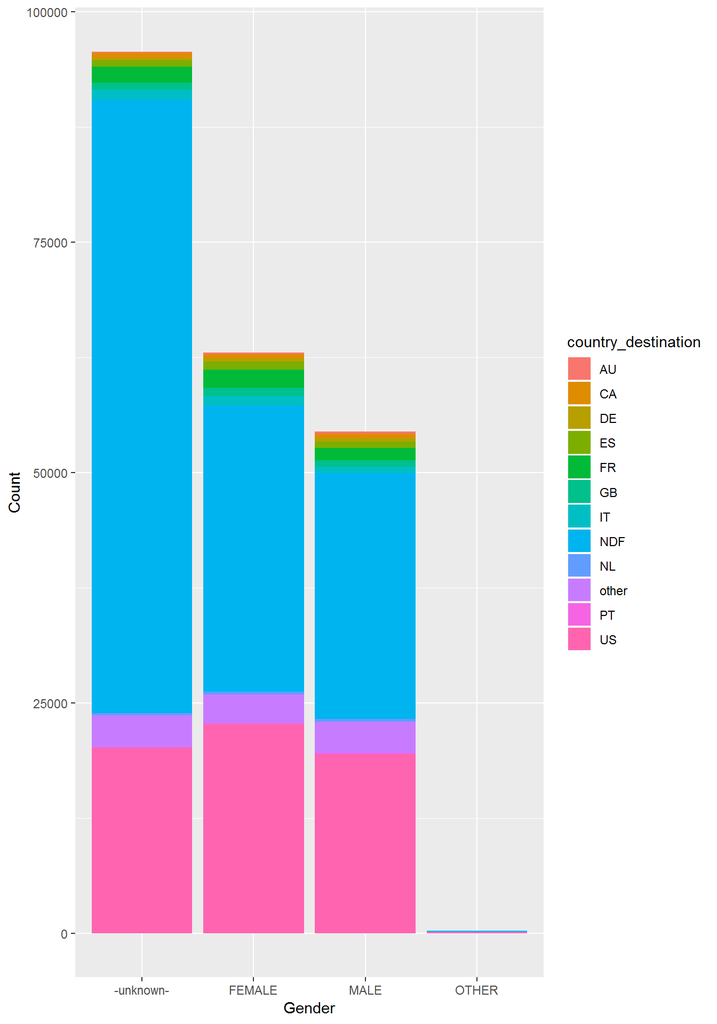

```r
# Make plot of gender by destination country
ggplot(merged_user, aes(x = gender, fill = country_destination)) +
  geom_bar()+
  xlab("Gender") +
  ylab("Count")
```

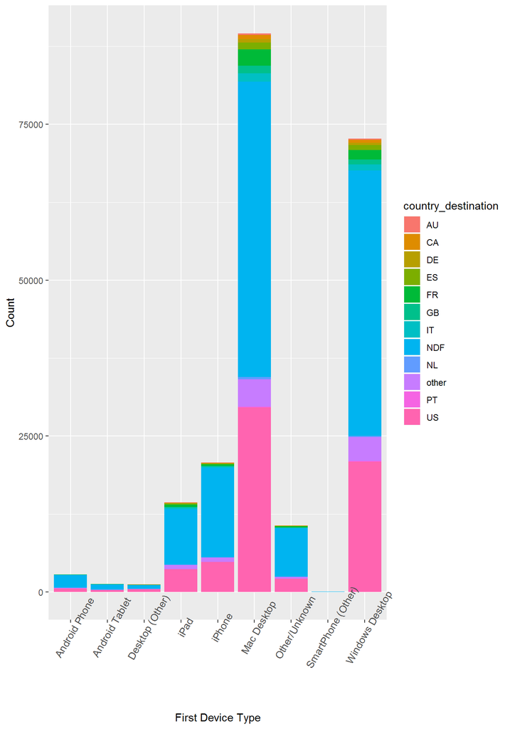

```r
# Make plot of device type by destination country
ggplot(merged_user, aes(x = first_device_type, fill = country_destination)) +
  geom_bar() +
  xlab("First Device Type") +
  ylab("Count") +
  theme(axis.text.x  = element_text(angle=60, hjust=0.5, size=10))
```

It is funny to see from the graph above that people using Android are less likely to travel compared with people using Apple and Windows.

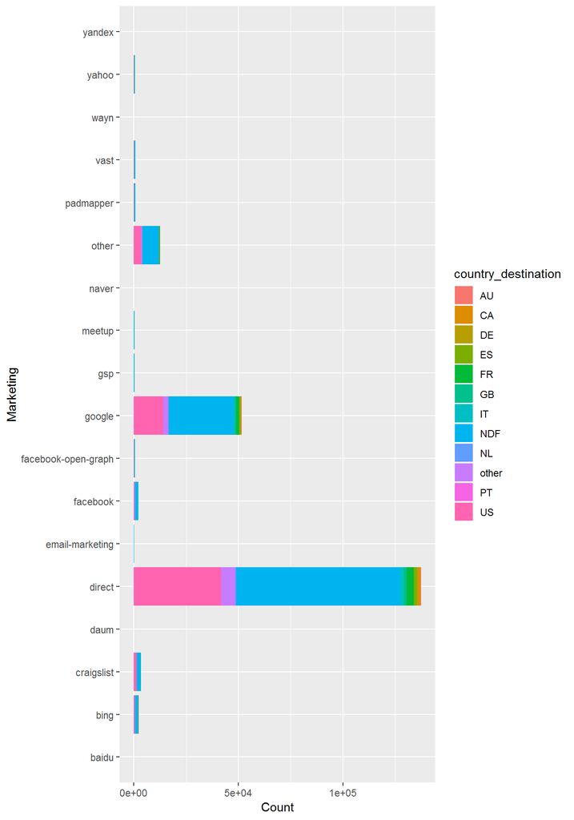

```r
# Make plot of affiliate provider by destination country
ggplot(merged_user, aes(x = affiliate_provider, fill = country_destination)) +
  geom_bar() +
  coord_flip()+
  xlab("Marketing") +
  ylab("Count")
```

From the graph above, we can see that people mostly look up and place order directly on Airbnb. The second largest source of visitors is Google.

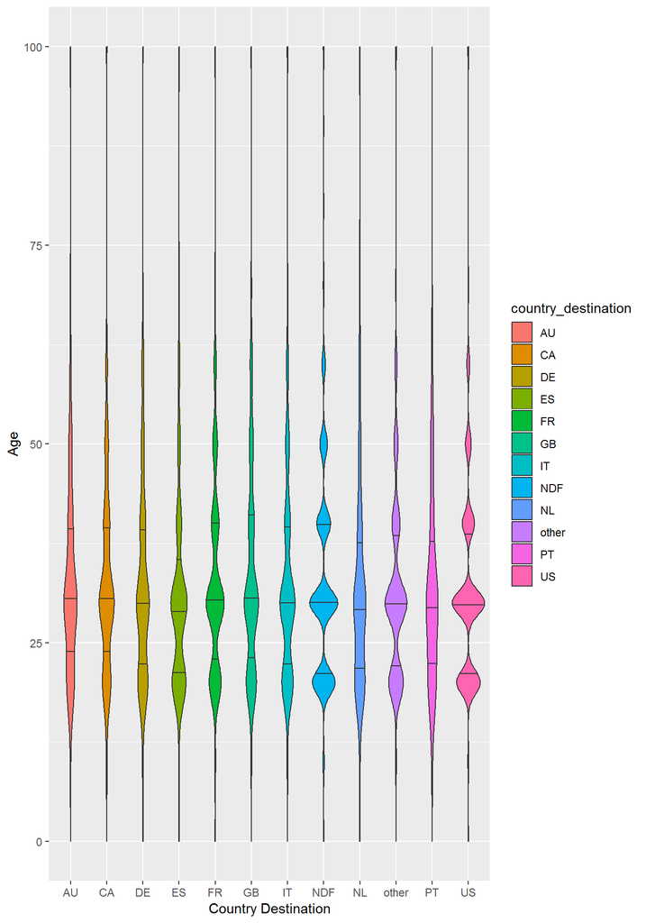

```r
# Make vilin plot of age by destination country
ggplot(merged_user, aes(x = country_destination, y = age, fill = country_destination)) +
  geom_violin(draw_quantiles = c(.25, .5, .75)) +
  xlab("Country Destination") +
  ylab("Age")
```

We can see that in addition to domestic travel, young Americans are more likely to travel to Spain, France, Portugal and Netherlands.

Next,We divided the target countries and devices into several categories to see the chioces of different genders and ages for these categories.

```r
# Divide countries into four categories
merged_user$country_category  <- NA
merged_user$country_category[which(merged_user$country_destination == "NDF")] <- 1
merged_user$country_category[which(merged_user$country_destination %in%
                                        c("US", "CA"))] <- 2
merged_user$country_category[which(merged_user$country_destination == "other")] <- 3
merged_user$country_category[which(merged_user$country_destination %in%
                          c("AU", "DE", "ES", "FR", "GB", "IT", "NL", "PT"))] <- 4
merged_user$country_category <- factor(merged_user$country_category, labels = c("None", "NotherAmerica", "Other", "Europe"))
```

```r
# Divide countries into two categories
merged_user$country_decision <- NA
merged_user$country_decision[which(merged_user$country_destination == "NDF")] <- 1
merged_user$country_decision[which(merged_user$country_destination %in%
                          c("US", "CA","AU", "DE", "ES", "FR", "GB", "IT", "NL", "PT", "other"))] <- 2
merged_user$country_decision <- factor(merged_user$country_decision, labels = c("No", "Yes"))
```

```r
# Divide divice type into three categories
merged_user$device_category <- NA
merged_user$device_category[which(merged_user$first_device_type %in%
                          c("Desktop (Other)", "Mac Desktop", "Windows Desktop"))] <- 1
merged_user$device_category[which(merged_user$first_device_type %in% c("iPad", "Android Tablet"))] <- 2
merged_user$device_category[which(merged_user$first_device_type %in%
                          c("Android Phone", "iPhone", "SmartPhone (Other)"))] <- 3
merged_user$device_category <- factor(merged_user$device_category, labels = c("Desktop", "Pad", "SmartPhone"))
```

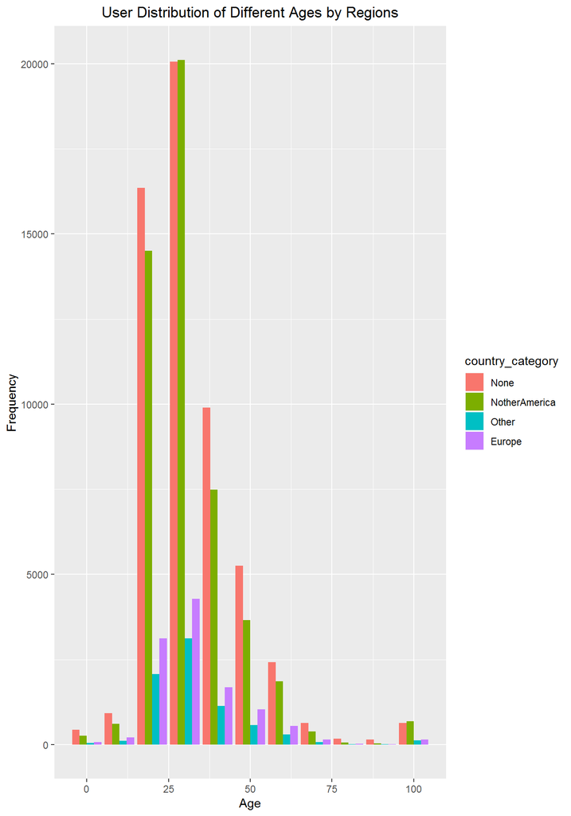

```r
# Make plot of age by country_category
ggplot(merged_user) +
  geom_bar(aes(x = age, fill = country_category), position = "dodge") +
  labs(x = "Age",
       y = "Frequency",
       title = "User Distribution of Different Ages by Regions",
       fill = "country_category") + theme(plot.title = element_text(hjust = 0.5))
```

We can see that people aged 20-40 are the main force in tourism consumption. Their first choice is domestic travel, followed by going to Europe.

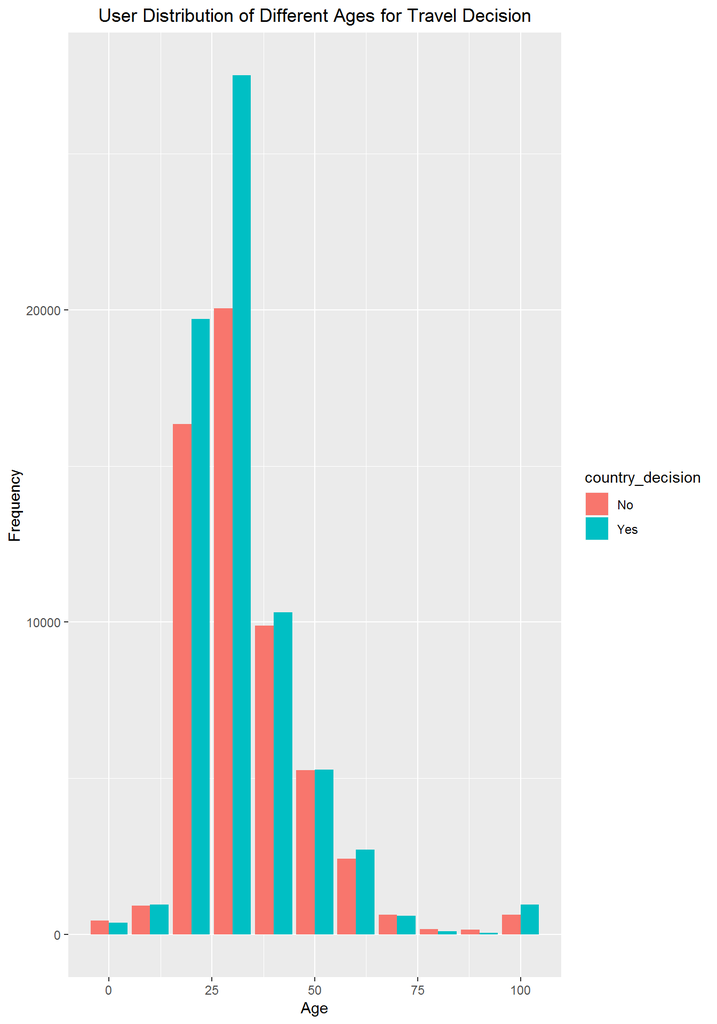

```r
# Make plot of age by country_decision
ggplot(merged_user) +
  geom_bar(aes(x = age, fill = country_decision), position = "dodge") +
  labs(x = "Age",
       y = "Frequency",
       title = "User Distribution of Different Ages for Travel Decision",
       fill = "country_decision") + theme(plot.title = element_text(hjust = 0.5))
```

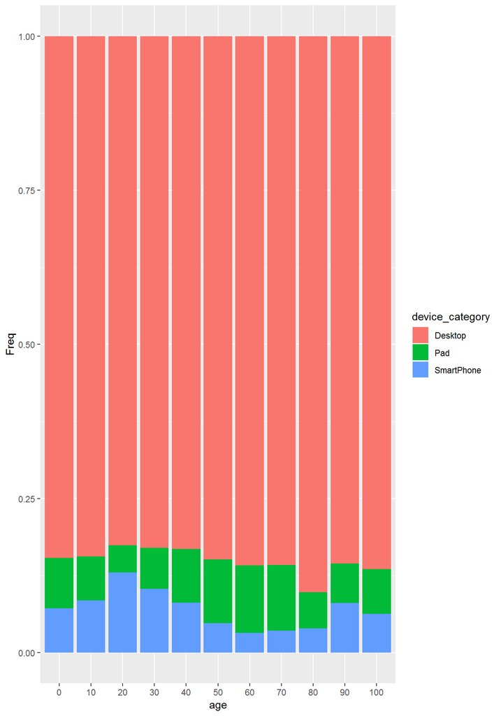

```r
# Make plot of age by device_category
t = table(merged_user$age, merged_user$device_category)
d = as.data.frame(t / rowSums(t))
names(d) = c("age", "device_category", "Freq")
print(ggplot(d, aes(age, Freq, fill=device_category)) + geom_bar(stat="identity"))
```

We can see that the vast majority of users browsed Airbnb information on the desktop.

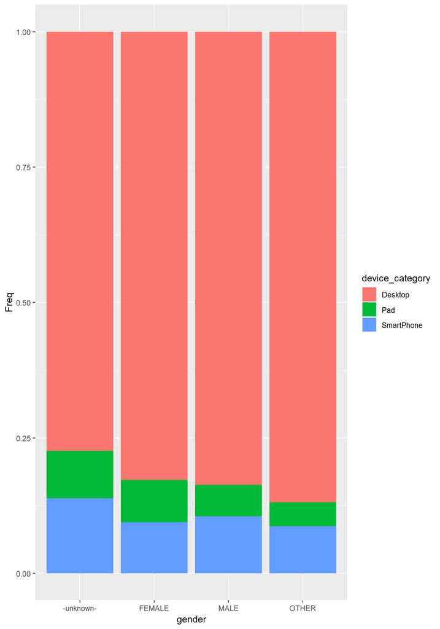

```r
# Make plot of gender by device_category
t = table(merged_user$gender, merged_user$device_category)
d = as.data.frame(t / rowSums(t))
names(d) = c("gender", "device_category", "Freq")
print(ggplot(d, aes(gender, Freq, fill=device_category)) + geom_bar(stat="identity"))
```

We can see that most of the users prefer to use desktop to browse Airbnb, followed by smartphone, then iPad.

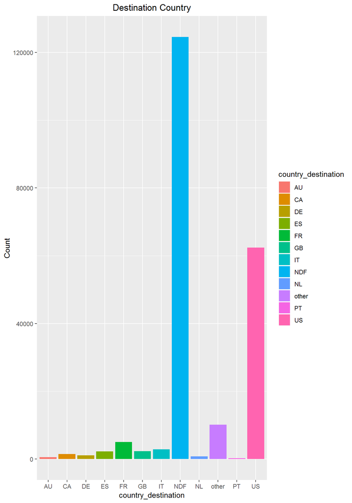

```r
# Make plot of country_destination
ggplot(merged_user)+
     geom_bar(aes(x = country_destination, fill = country_destination))+
     labs(x="country_destination",
          y="Count",
          title="Destination Country")+
     theme(plot.title = element_text(hjust = 0.5))
```

From the graph above, we can see that the target variable is highly unbalanced.

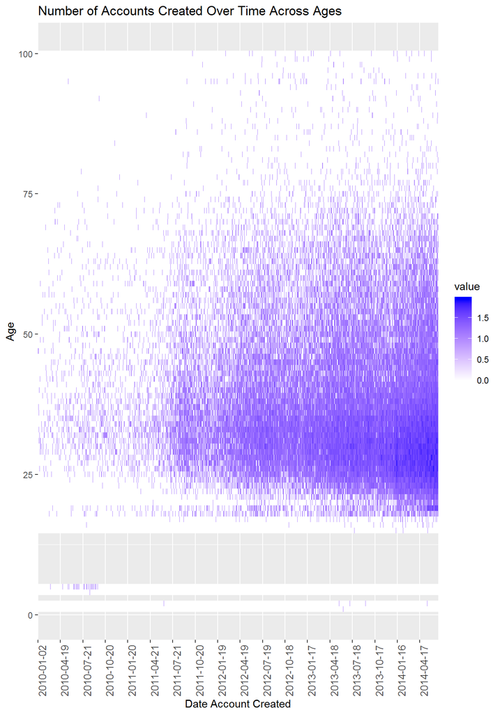

```r
# Number of Accounts Created Over Time Across Ages
train_user$date_account_created <- as.Date(train_user$date_account_created)
train_2_clean <- train_user[age>=0 & age<=100,]
heatmapData <- as.matrix(table(train_2_clean$age,train_2_clean$date_account_created)^.2)

qplot(x=Var2, y=Var1, data=melt(heatmapData), fill=value, geom="tile",
           xlab = "Date Account Created", ylab = "Age",
           main = "Number of Accounts Created Over Time Across Ages") +
     scale_x_discrete(breaks=levels(as.factor(train_2_clean$date_account_created))[c(TRUE, rep(FALSE, 90))],
                          labels=levels(as.factor(train_2_clean$date_account_created))[c(TRUE, rep(FALSE, 90))]) +
     theme(axis.text.x  = element_text(angle=90, hjust=0.5, size=10)) +
     scale_fill_gradient(low="white", high="blue")
```

From the graph above we can see that more people created their accounts recently, and those who created account are people age from 20 to 35.

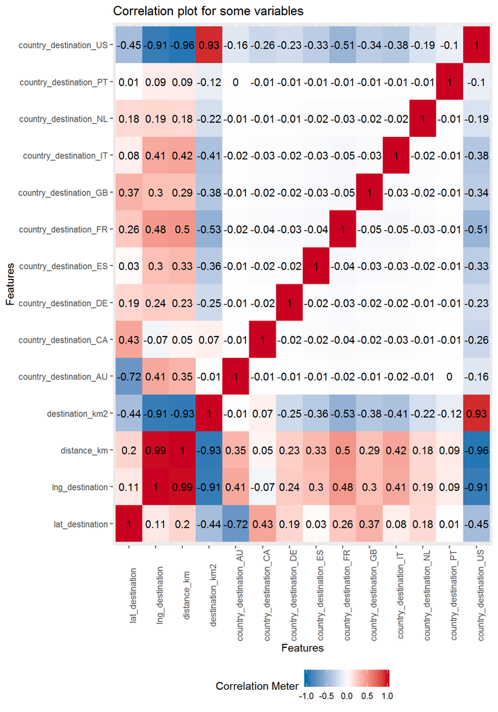

```r
# Make a correlation plot
plot_correlation(na.omit(merged_user[,1:5]),
                 title = "Correlation plot for some variables")
```

From the above Exploratory Data Analysis, we can see that there are subtle differences in the choices of destination countries for users of different ages, devices and browsers. Next, we will transpose all the factors into dummy variables and train the model to analyze the user’s choice of the destination country.

## 4. Data transformations

Prepare the data

```r
merged_user$country_destination <- as.factor(merged_user$country_destination)
merged_user$destination_language<- as.factor(merged_user$destination_language)
merged_user$gender<- as.factor(merged_user$gender)
merged_user$id<- as.factor(merged_user$id)
merged_user$signup_method<- as.factor(merged_user$signup_method)
merged_user$language<- as.factor(merged_user$language)
merged_user$affiliate_channel<- as.factor(merged_user$affiliate_channel)
merged_user$affiliate_provider<- as.factor(merged_user$affiliate_provider)
merged_user$first_affiliate_tracked<- as.factor(merged_user$first_affiliate_tracked)
merged_user$signup_app<- as.factor(merged_user$signup_app)
merged_user$first_device_type<- as.factor(merged_user$first_device_type)
merged_user$first_browser<- as.factor(merged_user$first_browser)
merged_user$year_account_created<- as.factor(merged_user$year_account_created)
merged_user$month_account_created<- as.factor(merged_user$month_account_created)
merged_user$day_account_created<- as.factor(merged_user$day_account_created)
merged_user$year_first_active<- as.factor(merged_user$year_first_active)
merged_user$month_first_active<- as.factor(merged_user$month_first_active)
merged_user$day_first_active<- as.factor(merged_user$day_first_active)
merged_user$year_month_account_created  <- as.factor(merged_user$year_month_account_created)
merged_user$year_month_account_created <- as.factor(merged_user$year_month_account_created)
merged_user$date_first_active <- as.factor(merged_user$date_first_active)
```

```r
# Select the columns which are to be used in the later analysis
new_user <- select(merged_user, country_destination, age, id, gender, signup_method, language, affiliate_channel, affiliate_provider, signup_app, first_device_type, first_browser)
```

```r
new_user[is.na(new_user)] <- -1


# Omit NA values in age column
new_user <- new_user[complete.cases(new_user[ , 2])]


# Cluster variables in first_browser column
new_user$first_browser[new_user$first_browser %in% c("Chrome","Chrome Mobile","Chromium")] <- "Chrome"
new_user$first_browser[new_user$first_browser %in% c("Firefox","Mobile Firefox","Mozilla")] <- "Firefox"
new_user$first_browser[new_user$first_browser %in% c("IE","IE Mobile")] <- "IE"
new_user$first_browser[new_user$first_browser %in% c("Mobile Safari","Safari")] <- "Safari"
new_user$first_browser[new_user$first_browser %in% c("Opera","Opera Mini","Opera Mobile")] <- "Firefox"
famousBrowsersSet <- c("Apple Mail", "Arora", "Camino", "CometBird", "Comodo Dragon", "Conkeror", "CoolNovo", "Epic", "Flock","Google Earth", "Googlebot", "IceDragon","IceWeasel", "Iron", "Maxthon", "NetNewsWire", "OmniWeb", "Outlook 2007", "Pale Moon", "RockMelt", "SeaMonkey", "Silk", "SiteKiosk", "Stainless", "TenFourFox")
new_user$first_browser[(new_user$first_browser %in% famousBrowsersSet)] <- "Other"
# Create dummy variables for those we want to dummify
catVars <- dummyVars(~ gender + signup_method + language + affiliate_channel + affiliate_provider+ signup_app + first_device_type + first_browser, data = new_user)
user_dummy <- data.frame(predict(catVars, newdata = new_user))
```

```r
# Combine the dummy variables and those are not dummy variables.
new_user_not_nominal <- select(new_user, country_destination, age, id)
new_user <- bind_cols(new_user_not_nominal, user_dummy)
```

## 5. Modeling

```r
# Split the data into training and validation set.
set.seed(4500)
data_split <- initial_split(new_user, strata = "country_destination")
cs_train <- training(data_split)
cs_test  <- testing(data_split)

#set.seed(2453)
#Cv_splits <- vfold_cv(cs_train, v = 10, strata = "country_destination")

classes = cs_train$country_destination
classes <- as.integer(recode(classes,NDF=0,US=1,other=2,FR=3,CA=4,GB=5,ES=6,IT=7,PT=8,NL=9,DE=10,AU=11))

test_classes = cs_test$country_destination
test_classes <- as.integer(recode(test_classes,NDF=0,US=1,other=2,FR=3,CA=4,GB=5,ES=6,IT=7,PT=8,NL=9,DE=10,AU=11))
```

```r
# Drop the original country_destination column
train_no_id = subset(cs_train, select = -c(country_destination, id))
test_no_id = subset(cs_test, select = -c(country_destination, id))
```

```r
train_no_id[is.na(train_no_id)] <- -1
testtest <- data.matrix(train_no_id)
```

### 1.Extreme Gradient Boosting

```r
# Make a matrix
xgb_test_matrix <- xgb.DMatrix(data = as.matrix(test_no_id), label = test_classes)
```

```r
parallel::detectCores(logical = TRUE)
```

```
## [1] 8
```

```r
set.seed(4500)
cl <- makeCluster(8)
registerDoParallel(cl)
```

```r
#Run XGB model
xgb <- xgboost(data = testtest,
               label = classes,
               eta = 0.1,
               max_depth = 9,
               nround = 100,
               subsample = 0.5,
               colsample_bytree = 0.5,
               seed = 1,
               eval_metric = "merror",
               objective = "multi:softprob",
               num_class = 12,
               nthread = 3
)
model <- xgb.dump(xgb, with_stats = T)
feature_names <- dimnames(data.matrix(train_no_id))[[2]]
feature_importance_matrix <- xgb.importance(feature_names, model = xgb)
print(feature_importance_matrix)
```

```
##                                    Feature         Gain        Cover
##  1:                                    age 3.667272e-01 1.137330e-01
##  2:                 signup_method.facebook 9.480537e-02 1.929243e-02
##  3:                       gender..unknown. 6.727089e-02 3.660231e-02
##  4:                    signup_method.basic 4.394315e-02 2.499088e-02
##  5:                            gender.MALE 2.344796e-02 2.200648e-02
##  6:          first_device_type.Mac.Desktop 2.221260e-02 1.889917e-02
##  7:                         signup_app.Web 2.165800e-02 2.644040e-02
##  8:        first_device_type.Other.Unknown 2.047898e-02 1.791672e-02
##  9:              affiliate_channel.content 1.984383e-02 2.655699e-02
## 10:                          gender.FEMALE 1.963444e-02 1.994616e-02
## 11:                   first_browser.Chrome 1.643524e-02 1.251556e-02
## 12:      first_device_type.Windows.Desktop 1.540711e-02 1.416305e-02
## 13:                   first_browser.Safari 1.422766e-02 1.491207e-02
## 14:                  first_browser.Firefox 1.344480e-02 1.296625e-02
```

[output cut: 151 more lines]

```r
y_pred <- predict(xgb, xgb_test_matrix)
predictions <- as.data.frame(matrix(y_pred, nrow=12))
rownames(predictions) <- c('NDF','US','other','FR','CA','GB','ES','IT','PT','NL','DE','AU')
```

```r
a <- t(predictions)
```

We extracted the top prediction for each user and created a confusion matrix for our prediction.

```r
# Print model
u <- union(cs_test$country_destination, as.factor(colnames(a)[apply(a,1,which.max)]))
t <- table(factor(cs_test$country_destination, u), factor(colnames(a)[apply(a,1,which.max)],u))
cm_xgb <- confusionMatrix(t)
cm_xgb
```

```
## Confusion Matrix and Statistics
##
##
##            AU    CA    DE    ES    FR    GB    IT   NDF    NL    PT    US
##   AU        0     0     0     0     0     0     0    62     0     0    72
##   CA        0     0     0     0     0     0     0   192     0     0   169
##   DE        0     0     0     0     0     0     0   150     0     0   114
##   ES        0     0     0     0     0     0     0   304     0     0   219
##   FR        0     0     0     0     0     0     0   727     0     0   555
##   GB        0     0     0     0     0     0     0   312     0     0   274
##   IT        0     0     0     0     0     0     0   400     0     0   318
##   NDF       0     0     0     0     0     0     0 26441     0     0  4659
##   NL        0     0     0     0     0     0     0   113     0     0    81
##   PT        0     0     0     0     0     0     0    34     0     0    23
##   US        0     0     0     0     0     0     0  8232     0     0  7345
##   other     0     0     0     0     0     0     0  1441     0     0  1125
##
##         other
##   AU        0
##   CA        0
##   DE        0
##   ES        0
##   FR        0
##   GB        0
##   IT        0
##   NDF       0
##   NL        0
##   PT        0
##   US        0
##   other     0
##
## Overall Statistics
##
##                Accuracy : 0.6331
##                  95% CI : (0.629, 0.6372)
##     No Information Rate : 0.7198
##     P-Value [Acc > NIR] : 1
##
##                   Kappa : 0.2644
##  Mcnemar's Test P-Value : NA
```

[output cut: 15 more lines]

```
## Pos Pred Value              NA        NA     0.8502        NA        NA
## Neg Pred Value              NA        NA     0.4624        NA        NA
## Prevalence             0.00000   0.00000     0.7198  0.000000  0.000000
## Detection Rate         0.00000   0.00000     0.4955  0.000000  0.000000
## Detection Prevalence   0.01098   0.01346     0.5828  0.003636  0.001068
## Balanced Accuracy           NA        NA     0.6884        NA        NA
##                      Class: US Class: other
## Sensitivity             0.4912           NA
## Specificity             0.7857      0.95191
## Pos Pred Value          0.4715           NA
## Neg Pred Value          0.7986           NA
## Prevalence              0.2802      0.00000
## Detection Rate          0.1376      0.00000
## Detection Prevalence    0.2919      0.04809
## Balanced Accuracy       0.6384           NA
```

```r
overall3 <- cm_xgb$overall
overall3.accuracy <- overall3['Accuracy']

overall3.kappa <- overall3['Kappa']


paste("We can see that the accuaracy is", overall3.accuracy, ", and the Kappa value is", overall3.kappa)
```

```
## [1] "We can see that the accuaracy is 0.633147183388929 , and the Kappa value is 0.264395237001809"
```

### 2. Recursive Partitioning

```r
# Let's split the data first
set.seed(4500)
data_split1 <- initial_split(new_user, strata = "country_destination")
cs_train1 <- training(data_split1)
cs_test1  <- testing(data_split1)

# drop the original id column and assign the value -1 to NA
train_no_id1 = subset(cs_train1, select = -c(id))
train_no_id1[is.na(train_no_id1)] <- -1
```

```r
# training
rp_mod <- rpart(
     country_destination~.,
     data=train_no_id1,
     xval = 10,
     method="class")
```

```r
# print out the model
print(rp_mod)
```

```
## n= 160089
##
## node), split, n, loss, yval, (yprob)
##       * denotes terminal node
##
## 1) root 160089 66646 NDF (0.0025 0.0067 0.005 0.011 0.023 0.011 0.013 0.58 0.0035 0.047 0.001 0.29)
##   2) age< -0.5 66134 15361 NDF (0.0012 0.004 0.0025 0.0065 0.015 0.0064 0.0091 0.77 0.0017 0.029 0.00068 0.16) *
##   3) age>=-0.5 93955 51285 NDF (0.0035 0.0085 0.0067 0.014 0.03 0.014 0.016 0.45 0.0048 0.06 0.0012 0.39)
##     6) signup_method.facebook>=0.5 43176 17364 NDF (0.0026 0.0054 0.0055 0.011 0.021 0.0099 0.012 0.6 0.0034 0.045 0.001 0.29) *
##     7) signup_method.facebook< 0.5 50779 26710 US (0.0042 0.011 0.0078 0.016 0.037 0.018 0.02 0.33 0.0061 0.073 0.0014 0.47) *
```

```r
rp_mod$finalModel
```

```r
# prediction
predictions1 <- predict(rp_mod, cs_test1, type = "class")

# Compare predicted outcome with the actual outcome to compute the out-of-sample accuracy of the model
cm <- confusionMatrix(predictions1, cs_test1$country_destination)
cm
```

```
## Confusion Matrix and Statistics
##
##           Reference
## Prediction    AU    CA    DE    ES    FR    GB    IT   NDF    NL other
##      AU        0     0     0     0     0     0     0     0     0     0
##      CA        0     0     0     0     0     0     0     0     0     0
##      DE        0     0     0     0     0     0     0     0     0     0
##      ES        0     0     0     0     0     0     0     0     0     0
##      FR        0     0     0     0     0     0     0     0     0     0
##      GB        0     0     0     0     0     0     0     0     0     0
##      IT        0     0     0     0     0     0     0     0     0     0
##      NDF      56   166   132   280   670   291   366 25575   100  1299
##      NL        0     0     0     0     0     0     0     0     0     0
##      other     0     0     0     0     0     0     0     0     0     0
##      PT        0     0     0     0     0     0     0     0     0     0
##      US       78   195   132   243   612   295   352  5525    94  1267
##           Reference
## Prediction    PT    US
##      AU        0     0
##      CA        0     0
##      DE        0     0
##      ES        0     0
##      FR        0     0
##      GB        0     0
##      IT        0     0
##      NDF      31  7567
##      NL        0     0
##      other     0     0
##      PT        0     0
##      US       26  8010
##
## Overall Statistics
##
##                Accuracy : 0.6294
##                  95% CI : (0.6253, 0.6335)
##     No Information Rate : 0.5828
##     P-Value [Acc > NIR] : < 2.2e-16
##
##                   Kappa : 0.2718
##  Mcnemar's Test P-Value : NA
```

[output cut: 15 more lines]

```
## Pos Pred Value             NaN       NaN     0.7001       NaN          NaN
## Neg Pred Value         0.98902   0.98654     0.6717  0.996364      0.95191
## Prevalence             0.01098   0.01346     0.5828  0.003636      0.04809
## Detection Rate         0.00000   0.00000     0.4793  0.000000      0.00000
## Detection Prevalence   0.00000   0.00000     0.6846  0.000000      0.00000
## Balanced Accuracy      0.50000   0.50000     0.6651  0.500000      0.50000
##                      Class: PT Class: US
## Sensitivity           0.000000    0.5142
## Specificity           1.000000    0.7666
## Pos Pred Value             NaN    0.4760
## Neg Pred Value        0.998932    0.7929
## Prevalence            0.001068    0.2919
## Detection Rate        0.000000    0.1501
## Detection Prevalence  0.000000    0.3154
## Balanced Accuracy     0.500000    0.6404
```

```r
overall <- cm$overall
overall.accuracy <- overall['Accuracy']

overall.kappa <- overall['Kappa']


paste("We can see that the accuracy is", overall.accuracy, ", and the Kappa value is", overall.kappa)
```

```
## [1] "We can see that the accuracy is 0.629380458003823 , and the Kappa value is 0.27176800227394"
```

### 3. Random Forest

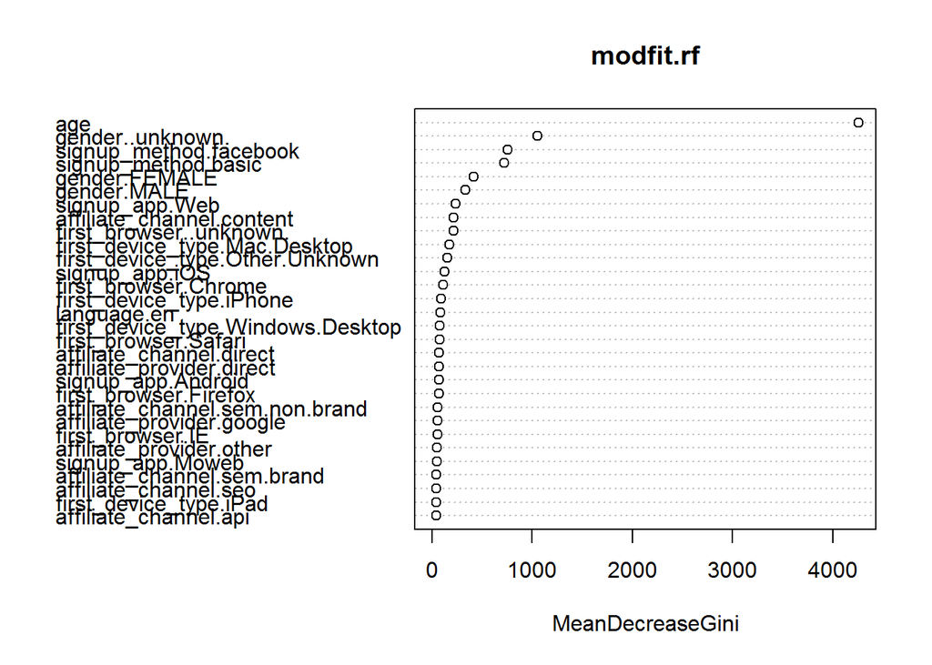

```r
# training
modfit.rf <- randomForest(country_destination ~. , data=train_no_id1)

# prediction
predictions2 <- predict(modfit.rf, cs_test1, type = "class")

varImpPlot(modfit.rf)
```

```r
# Compare predicted outcome with the actual outcome to compute the out-of-sample accuracy of the model
rfc <- confusionMatrix(predictions2, cs_test1$country_destination)
rfc
```

```
## Confusion Matrix and Statistics
##
##           Reference
## Prediction    AU    CA    DE    ES    FR    GB    IT   NDF    NL other
##      AU        0     0     0     0     0     0     0     0     0     0
##      CA        0     0     0     0     0     0     0     0     0     0
##      DE        0     0     0     0     0     0     0     0     0     0
##      ES        0     0     0     0     0     0     0     0     0     0
##      FR        0     0     0     0     0     0     0     0     0     0
##      GB        0     0     0     0     0     0     0     0     0     0
##      IT        0     0     0     0     0     0     0     0     0     0
##      NDF      67   186   142   305   726   308   394 26430   113  1432
##      NL        0     0     0     0     0     0     0     0     0     0
##      other     0     0     0     0     0     0     0     0     0     0
##      PT        0     0     0     0     0     0     0     0     0     0
##      US       67   175   122   218   555   277   323  4619    81  1129
##           Reference
## Prediction    PT    US
##      AU        0     0
##      CA        0     0
##      DE        0     0
##      ES        0     0
##      FR        0     0
##      GB        0     0
##      IT        0     0
##      NDF      35  8269
##      NL        0     0
##      other     0     0
##      PT        0     0
##      US       22  7278
##
## Overall Statistics
##
##                Accuracy : 0.6327
##                  95% CI : (0.6286, 0.6368)
##     No Information Rate : 0.5828
##     P-Value [Acc > NIR] : < 2.2e-16
##
##                   Kappa : 0.2631
##  Mcnemar's Test P-Value : NA
```

[output cut: 15 more lines]

```
## Pos Pred Value             NaN       NaN     0.6882       NaN          NaN
## Neg Pred Value         0.98902   0.98654     0.6893  0.996358      0.95193
## Prevalence             0.01098   0.01346     0.5828  0.003642      0.04807
## Detection Rate         0.00000   0.00000     0.4961  0.000000      0.00000
## Detection Prevalence   0.00000   0.00000     0.7209  0.000000      0.00000
## Balanced Accuracy      0.50000   0.50000     0.6562  0.500000      0.50000
##                      Class: PT Class: US
## Sensitivity            0.00000    0.4681
## Specificity            1.00000    0.7989
## Pos Pred Value             NaN    0.4896
## Neg Pred Value         0.99893    0.7847
## Prevalence             0.00107    0.2918
## Detection Rate         0.00000    0.1366
## Detection Prevalence   0.00000    0.2791
## Balanced Accuracy      0.50000    0.6335
```

```r
overall2 <- rfc$overall
overall2.accuracy <- overall2['Accuracy']

overall2.kappa <- overall2['Kappa']


paste("We can see that the accuracy is", overall2.accuracy, ", and the Kappa value is", overall2.kappa)
```

```
## [1] "We can see that the accuracy is 0.632740788016444 , and the Kappa value is 0.263085247596062"
```

Then we compare three models.

```r
Fianl_Accuracy <- c(overall3.accuracy,overall.accuracy,overall2.accuracy)
Final_Kappa <- c(overall3.kappa, overall.kappa, overall2.kappa)
title <- c("XGBoost", "Rpart", "Random Forest")
r_table <- data.frame("Model" = title, "Accuracy"=Fianl_Accuracy, "Kappa" = Final_Kappa)
r_table
```

```
##           Model  Accuracy     Kappa
## 1       XGBoost 0.6331472 0.2643952
## 2         Rpart 0.6293805 0.2717680
## 3 Random Forest 0.6327408 0.2630852
```

## 6. Final discussion

# Prediction

```r
test_user <- as.data.table(test_user)
```

```r
# Do the similar preprocess
test_user$age[is.na(test_user$age)] <- -1
test_user$age[test_user$age > 1900] <- 2015 - test_user$age[test_user$age > 1900]
test_user$age[(test_user$age < 10) & (test_user$age >= 0)] <- 0
test_user$age[(test_user$age < 20) & (test_user$age >= 10)] <- 10
test_user$age[(test_user$age < 30) & (test_user$age >= 20)] <- 20
test_user$age[(test_user$age < 40) & (test_user$age >= 30)] <- 30
test_user$age[(test_user$age < 50) & (test_user$age >= 40)] <- 40
test_user$age[(test_user$age < 60) & (test_user$age >= 50)] <- 50
test_user$age[(test_user$age < 70) & (test_user$age >= 60)] <- 60
test_user$age[(test_user$age < 80) & (test_user$age >= 70)] <- 70
test_user$age[(test_user$age < 90) & (test_user$age >= 80)] <- 80
test_user$age[(test_user$age < 100) & (test_user$age >= 90)] <- 90
test_user$age[test_user$age >= 100] <- 100
test_user$age[test_user$age == -1] <- NA
```

```r
test_user$gender<- as.factor(test_user$gender)
test_user$id<- as.factor(test_user$id)
test_user$signup_method<- as.factor(test_user$signup_method)
test_user$language<- as.factor(test_user$language)
test_user$affiliate_channel<- as.factor(test_user$affiliate_channel)
test_user$affiliate_provider<- as.factor(test_user$affiliate_provider)
test_user$first_affiliate_tracked<- as.factor(test_user$first_affiliate_tracked)
test_user$signup_app<- as.factor(test_user$signup_app)
test_user$first_device_type<- as.factor(test_user$first_device_type)
test_user$first_browser<- as.factor(test_user$first_browser)
```

```r
# select the columns which are to be used in the later analysis
new_user2 <- select(test_user, age, id, gender, signup_method, language, affiliate_channel, affiliate_provider, signup_app, first_device_type, first_browser)
```

```r
new_user2[is.na(new_user2)] <- -1

# omit NA values in age column
new_user2 <- new_user2[complete.cases(new_user2[ , 2])]

# cluster variables in first_browser column
new_user2$first_browser[new_user2$first_browser %in% c("Chrome","Chrome Mobile","Chromium")] <- "Chrome"
new_user2$first_browser[new_user2$first_browser %in% c("Firefox","Mobile Firefox","Mozilla")] <- "Firefox"
new_user2$first_browser[new_user2$first_browser %in% c("IE","IE Mobile")] <- "IE"
new_user2$first_browser[new_user2$first_browser %in% c("Mobile Safari","Safari")] <- "Safari"
new_user2$first_browser[new_user2$first_browser %in% c("Opera","Opera Mini","Opera Mobile")] <- "Firefox"
famousBrowsersSet <- c("Apple Mail", "Arora", "Camino", "CometBird", "Comodo Dragon", "Conkeror", "CoolNovo", "Epic", "Flock","Google Earth", "Googlebot", "IceDragon","IceWeasel", "Iron", "Maxthon", "NetNewsWire", "OmniWeb", "Outlook 2007", "Pale Moon", "RockMelt", "SeaMonkey", "Silk", "SiteKiosk", "Stainless", "TenFourFox")
new_user2$first_browser[(new_user2$first_browser %in% famousBrowsersSet)] <- "Other"
# create dummy variables for those we want to dummify
catVars2 <- dummyVars(~ gender + signup_method + language + affiliate_channel + affiliate_provider+ signup_app + first_device_type + first_browser, data = new_user2)
user_dummy2 <- data.frame(predict(catVars2, newdata = new_user2))
```

```r
# combine the dummy variables and those are not dummy variables.
new_user_not_nominal2 <- select(new_user2, age, id)
new_user2 <- bind_cols(new_user_not_nominal2, user_dummy2)
new_user2$id <- NULL
```

```r
new_user2$language.hr <- 0
new_user2$language.is <- 0
new_user2$affiliate_channel.api <- 0
new_user2$affiliate_provider.wayn <- 0
new_user2$first_browser.Arora <- 0
new_user2$first_browser.Avant.Browser <- 0
new_user2$first_browser.Camino <- 0
new_user2$first_browser.Comodo.Dragon <- 0
new_user2$first_browser.Conkeror <- 0
new_user2$first_browser.CoolNovo <- 0
new_user2$first_browser.Crazy.Browser <- 0
new_user2$first_browser.Epic <- 0
new_user2$first_browser.Flock <- 0
new_user2$first_browser.Google.Earth <- 0
new_user2$first_browser.Googlebot <- 0
new_user2$first_browser.IceDragon <- 0
new_user2$first_browser.Kindle.Browser <- 0
new_user2$first_browser.Mozilla <- 0
new_user2$first_browser.NetNewsWire <- 0
new_user2$first_browser.OmniWeb <- 0
new_user2$first_browser.Outlook.2007 <- 0
new_user2$first_browser.Palm.Pre.web.browser <- 0
new_user2$first_browser.PS.Vita.browser <- 0
new_user2$first_browser.RockMelt <- 0
new_user2$first_browser.SlimBrowser <- 0
new_user2$first_browser.Stainless <- 0
new_user2$first_browser.TenFourFox <- 0
new_user2$first_browser.TheWorld.Browser <- 0
```

```r
# prediction
final_predict <- predict(modfit.rf,newdata = new_user2, type = "class")

final_predict
```

[output not shown]

[output cut: 10296 more lines]

[output not shown]

We can see that our prediction results don’t give us much information about users’ first booking destination since there’re only two classes, US and NDF. This means that most of the users will first book a place in the U.S. or they will not book according to our prediction. This is because our data is highly imbalanced, and the classifiers tend to be biased towards the majority class (i.e. US and NDF) and hence perform poorly on the minority class. Besides, we can see that many of the attributes are not useful in training the model, and our raw data is intuitively not very relevant to the results what we need to predict. If the original data contains more variables, such as the user’s previous hotel and ticket consumption records, our predicted results will be more accurate. Another reason that may affect our results is that we did not include date-related variables. After research, we found that a large number of users were not recorded for those variables. So if we use them, it will greatly reduce the size of sample we can use.